# Intro to Effective Teaching (TA) Practices

Matthew Beckman  
Director of Undergraduate Programs | Department of Statistics

August 15, 2018

[figure not shown]

https://m.xkcd.com/552/

# Outline

#### Part 1: Effective teaching (TA-ing)

- How do you learn most efficiently??
- ASA endorsed Guidelines for Assessment & Instruction in Statistics Education (GAISE, 2016)

#### Part 2: Being an effective teacher (TA)

- Running Labs
- Office Hours
- Student Email
- Grading
- General Tips (everyone)

# How do you learn most efficiently??

### The way *you* learn most efficiently may not be optimal for *everyone* … and **maybe not even most**

- Some students will learn and succeed no matter how good or bad the teaching
- Students in the same course may have very different reasons for being there (producers & consumers)
- The challenge is generally to optimize the efficiency of teaching & learning so that you are doing the most good for the most students
- see Garfield & Ben-Zvi (2007) for a review of statistics teaching and learning research

[figure not shown]

# ASA’s GAISE Guidelines

- This is the latest in several iterations of recommendations for statistics education
- The document reads with a bias toward introductory courses (because that’s the widest audience), but most principles apply readily to more advanced courses
- Several appendices with lots of examples, ideas, resources, and references

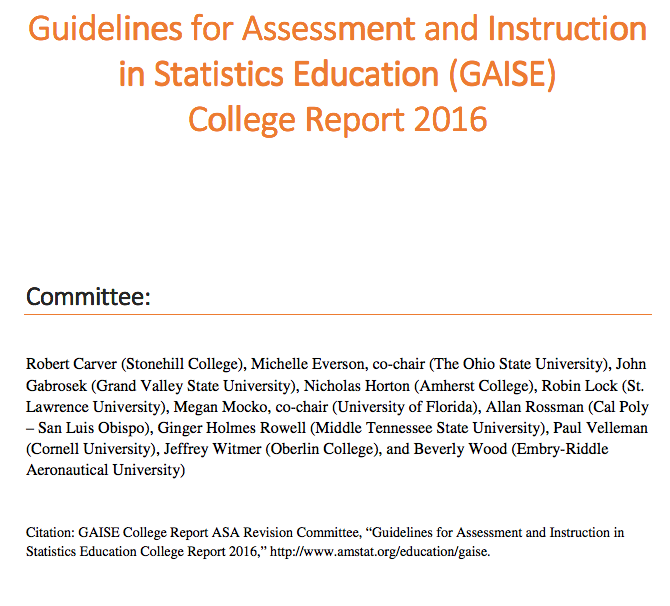

# The GAISE Recommendations

1. Teach statistical thinking
   - Teach statistics as an investigative process of problem-solving & decision-making
   - Give students experience with multivariable thinking
2. Focus on conceptual understanding
3. Integrate real data with a context and purpose
4. Foster active learning
5. Use technology to explore concepts and analyze data
6. Use assessments to improve and evaluate student learning

# The GAISE Recommendations

1. **Teach statistical thinking**
   - Teach statistics as an investigative process of problem-solving & decision-making
   - Give students experience with multivariable thinking

Use the content of the course as a platform to demonstrate *how statisticians think* to your students.

# The GAISE Recommendations

1. Teach statistical thinking
   - Teach statistics as an investigative process of problem-solving & decision-making
   - Give students experience with multivariable thinking
2. **Focus on conceptual understanding**

Developing sound intuition and promoting synthesis is generally more valuable than practicing the mechanics of seemingly disjoint methods

# The GAISE Recommendations

1. Teach statistical thinking
   - Teach statistics as an investigative process of problem-solving & decision-making
   - Give students experience with multivariable thinking
2. Focus on conceptual understanding
3. **Integrate real data with a context and purpose**

In general, the point you want to make–*and the reason you want to make it*–is much more compelling to students within the context of real data than through the use of a “toy” or contrived data set.

# The GAISE Recommendations

1. Teach statistical thinking
   - Teach statistics as an investigative process of problem-solving & decision-making
   - Give students experience with multivariable thinking
2. Focus on conceptual understanding
3. Integrate real data with a context and purpose
4. **Foster active learning**

*Generally, no more than 15 minutes should go by without students doing something active*

# The GAISE Recommendations

1. Teach statistical thinking
   - Teach statistics as an investigative process of problem-solving & decision-making
   - Give students experience with multivariable thinking
2. Focus on conceptual understanding
3. Integrate real data with a context and purpose
4. Foster active learning
5. **Use technology to explore concepts and analyze data**

Statistical software, Shiny Apps, Web Applets, etc, are powerful resources to promote learning and seperate superficial details from structural details

# The GAISE Recommendations

1. Teach statistical thinking
   - Teach statistics as an investigative process of problem-solving & decision-making
   - Give students experience with multivariable thinking
2. Focus on conceptual understanding
3. Integrate real data with a context and purpose
4. Foster active learning
5. Use technology to explore concepts and analyze data
6. **Use assessments to improve and evaluate student learning**

#### Assessment of learning, as learning, and for learning (Garfield & Franklin, 2011)

Assessment *of* learning [summative]: Measure student learning outcomes

Assessment *as* learning [formative]: Informs the trajectory of learning and instruction

Assessment *for* learning [evaluative]: **Students** use assessments to reflect on their learning strategy; **Instructors/TAs** Use assessments to learn about your class, and modify instruction accordingly

# Part 1: Good teaching (TA-ing)

- Student-centered learning
  - opportunities for students to learn by doing (both guided & independent practice)
  - Teach at the right level
    - challenge students, but make sure they are keeping up
    - *no questions* might be a sign that things are either too easy or too hard
- Always try to use real data with a context & purpose
- Emphasize concepts, critical thinking, & problem solving, not just calculations

# Part 2: Being a good teacher (TA)

- Running Labs
- Office Hours
- Student Email
- Grading
- General Tips (everyone)

# Small Group Discussion

- Break into groups with a few of the people nearby
- Include at least one experienced TA in each group if possible
- Each group will be assigned one (or two) of the following discussion topics:
  1. Running Labs
  2. Office Hours
  3. Student Email
  4. Grading
  5. General Tips (everyone)

Spend a few minutes listing tips & recommendations. If you haven’t been a TA or instructor before, think about what your own TA’s & instructors have done well.

# Running Labs

1. **Running Labs**
2. Office Hours
3. Student Email
4. Grading
5. General Tips (everyone)

# Running Labs

- Work through lab in advance
  - it’s okay if you make a mistake
  - it’s not okay to be routinely unprepared
- Walk around and engage with students (especially when you aren’t presenting)
- Help them learn how to debug for themselves
- Encourage collaboration
- Be approachable

# Office Hours

1. Running Labs
2. **Office Hours**
3. Student Email
4. Grading
5. General Tips (everyone)

# Office Hours

- Be familiar with current course material in advance (topics, terminology, notation…)
- The goal is learning, not just correct answers
  - Don’t just give answers
    - give guidance as needed to help them figure it out
    - direct them to a solved example in the book or notes
  - Be patient… let the student do the writing (computing, etc)
- Encourage students to work together
- Use the board (Better yet have students use the board if possible)
- Concrete examples help when explaining concepts (draw a picture, show them an example in the book, etc)

# Student email

1. Running Labs
2. Office Hours
3. **Student Email**
4. Grading
5. General Tips (everyone)

# Student email

- Make sure students know your email and know they can contact you
- Respond in a timely manner (within 24 hours)
- Email is best for short, straightforward replies
- For longer subject matter questions, give a short remark and refer them to office hours or a helpful example in the book/notes
- **Don’t let emails go unanswered**

# Grading

1. Running Labs
2. Office Hours
3. Student Email
4. **Grading**
5. General Tips (everyone)

# Grading

- Be fair & consistent
  - use a rubric, checklist, etc. with predetermined criteria associated with point values whenever possible… save this so you can show students exactly how they were graded
  - grade one problem (or page) for the whole class, then the next problem (or page) for the whole class, and so on
- Provide useful feedback; help them learn from their mistakes
- Stay in touch with the instructor
- Try to be efficient/timely
- Keep a document of common mistakes (and feedback)

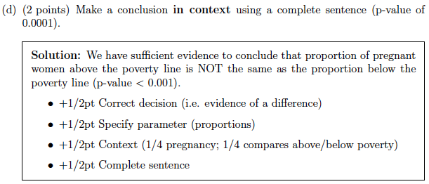

Rubric example

# General

1. Running Labs
2. Office Hours
3. Student Email
4. Grading
5. **General Tips (everyone)**

# General

- Always treat students with respect
- Care about your students and sincerely want them to succeed
- Students will often mirror your demeanor
- Be friendly & approachable
- Professional relationship with students
  - Be kind but in charge
  - Always maintain a united front with the faculty & TA’s

# References

GAISE College Report ASA Revision Committee (2016). *Guidelines for Assessment and Instruction in Statistics Education (GAISE) College Report 2016*, http://www.amstat.org/education/gaise.

Garfield, J. and Ben-Zvi, D. (2007). How students learn statistics revisited: A current review of research on teaching and learning statistics. *International Statistical Review 75*(3).

Garfield, J. and Franklin, C. (2011). Assessment of learning, for learning, and as learning in statistics education. In C. Batanero, G. Burrill, C. Reading, and A. Rossman (eds.). *Teaching statistics in school mathematics - Challenges for teaching and teacher education: A joint ICMI/IASE Study* (pp. 133-145). New York: Springer.